# Predicting the Weather

```r
library(car)
library(tidyverse)
library(ggplot2)
library(pander)
library(DT)
data <- read.csv("weatherdata.csv", header=TRUE)
#View(data)
```

## Background

This is a statistical model that seeks to predict the maximum air temperature based on data from two days before the day you actually want to predict. For this analysis, we’ll predict the max air temperature of September 23rd, 2019.

## Data collection

I collected data from http://www.timeanddate.com. I randomly selected 12 dates antime from 2011-2019 using the zip code 83440 (Rexburg, ID), then when ahead and recorded the max temperature from that day (which is the Y value) and the max temperature from two days ago (the X value).

## Linear Model

Our study is very simple: can we predict the max temperature of the after tomorrow using the max temperature of today? We’ll use a linear regression model to do that. The red lines indicate the interval of prediction.

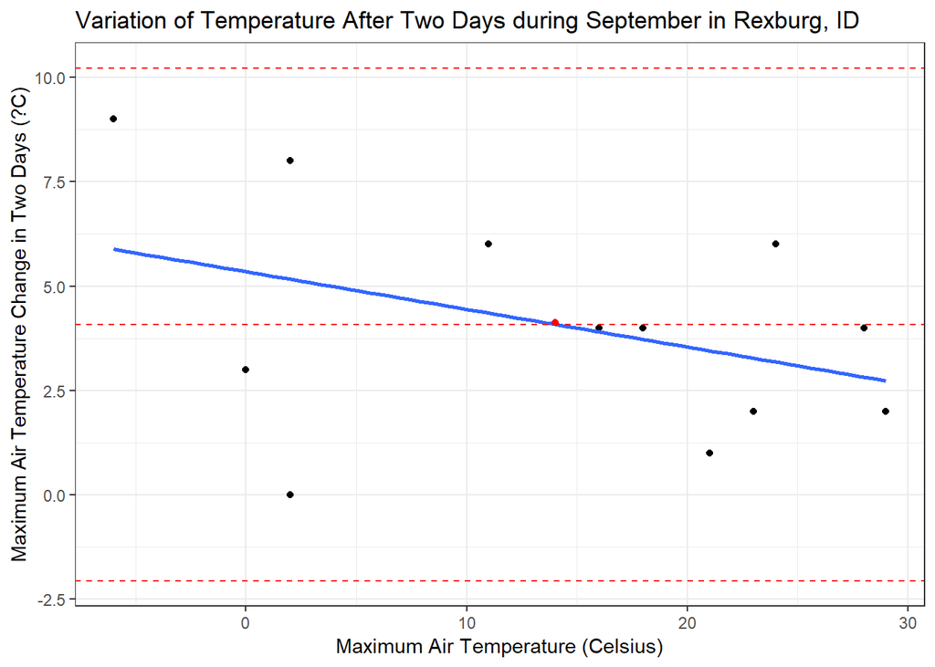

```r
regression <- lm(Change ~ HighTwoDaysBefore, data = data)

#It predicts a range for the HighTwoDaysBefore
preds <- predict(regression, data.frame(HighTwoDaysBefore = 14), interval = "prediction")

ggplot(data, aes(x = HighTwoDaysBefore, y = Change)) + geom_point() + geom_smooth(method = 'lm', se = FALSE) + labs(title="Variation of Temperature After Two Days during September in Rexburg, ID", x = "Maximum Air Temperature (Celsius)", y = "Maximum Air Temperature Change in Two Days (?C)") + theme_bw() + geom_point(x = 14, y = 4.13, color="red") + geom_hline(yintercept = preds[1], linetype="dashed", color = "red") + geom_hline(yintercept = preds[2], linetype="dashed", color = "red") + geom_hline(yintercept = preds[3], linetype="dashed", color = "red")
```

```r
pander(summary(regression))
```

|  | Estimate | Std. Error | t value | Pr(>\|t\|) |
| --- | --- | --- | --- | --- |
| **(Intercept)** | 5.345 | 1.21 | 4.417 | 0.001301 |
| **HighTwoDaysBefore** | -0.09015 | 0.067 | -1.346 | 0.2081 |

Fitting linear model: Change ~ HighTwoDaysBefore

| Observations | Residual Std. Error | $R^2$ | Adjusted $R^2$ |
| --- | --- | --- | --- |
| 12 | 2.65 | 0.1533 | 0.06864 |

From this analysis, we get the following statistical model:

$$\underbrace{Y_i}_\text{Change After Two Days} = \beta_0 + \beta_1\underbrace{X_i}_\text{Current Max Temp} + \epsilon_i \quad \text{where} \ \epsilon_i \sim N(0,\sigma^2)$$

Plotting the new slope and intercept, we get the following predictive model:
$$\underbrace{\hat{Y}_i}_\text{Predicted Change After Two Days} = 5.34 - 0.09 \underbrace{X_i}_\text{Current Max Temp}$$
The *interpreation* of this model goes as follow: Starting at the Y intercept (5.34 degrees celsius), there’s a decrease of 0.09 degrees in the average change of temperature. In other words, as the current max temperature increases, there will be less change in the average highest temperature, after two days.

To know the maximum air temperature of the day after tomorrow, we’d just have to add $Y_i$ to today’s maximum air temperature. So the predicted weather would be:
$$\text{Predicted Weather}\ = \underbrace{\hat{Y}_i}_\text{Predicted Change After Two Days} + \underbrace{X_i}_\text{Current Max Temp}$$

## Diagnostic Plots

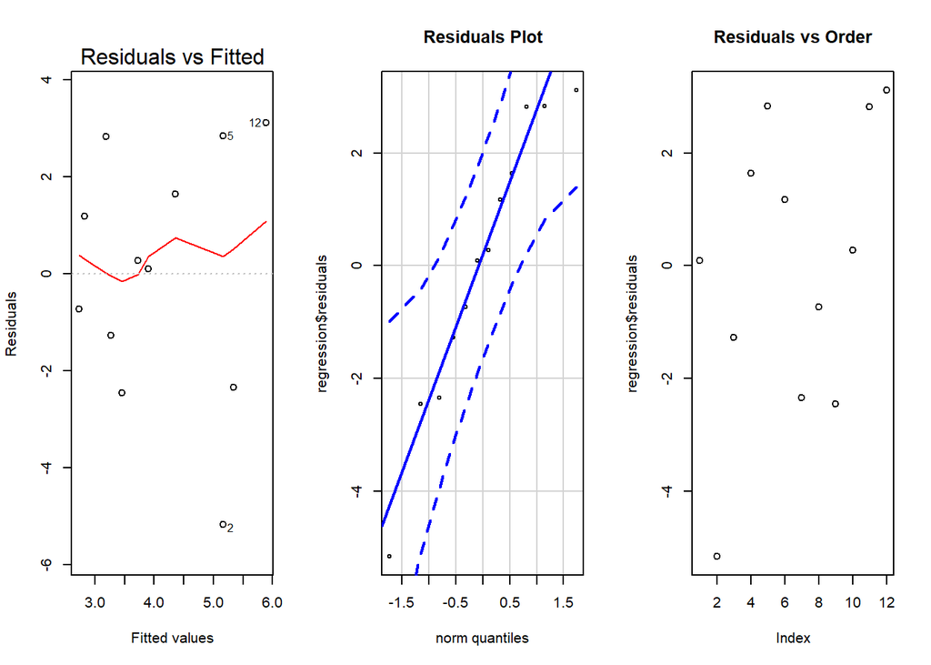

```r
par(mfrow=c(1,3))
plot(regression, which=1)
qqPlot(regression$residuals, id=FALSE, main="Residuals Plot")
plot(regression$residuals, main="Residuals vs Order")
```

As seen in the first diagnostic plot, there’s no discernable pattern when we plot fitted values vs. residuals (this means: 1. there’s a linear relationship, and 2.the variance in errors is constant through out x-values). The second plot tells us the residuals are normally distributed (which mean our second assumption isn’t violated either). Finally, as seen in the third plot, when ordered, the residuals don’t show any pattern, which means the errors are independent: no assumptions have been violated.

## Prediction for Sept 23rd, 2019

The highest temperature of today Saturday ($X_i$) is *14* degrees celsius, according to our model it will change 4.13 degree, but in terms of intervals, the change can be anywhere from 10.23 degrees to -2.06 (see red lines in the graph). So the *predicted highest temperature for Monday is 18* (see red dot in the graph above) or *anywhere from 12 - 24.23 degrees celsius*.

Because our null hypothesis is that there’s no slope ($\beta_1 = 0$) or significant correlation and we got a p-value of *0.2*, being a our significance level is $\alpha = 0.05$, we can say that there’s not enough evidence to reject the hypothesis. In other words, the slope term is not significant and we shouln’t trust this model.

## Data

```r
pander(data)
```

| Day | Month | Year | HighDayofPrediction | HighTwoDaysBefore | Change |
| --- | --- | --- | --- | --- | --- |
| 19 | 9 | 2019 | 20 | 16 | 4 |
| 14 | 1 | 2014 | 2 | 2 | 0 |
| 5 | 6 | 2019 | 25 | 23 | 2 |
| 17 | 4 | 2016 | 17 | 11 | 6 |
| 9 | 3 | 2017 | 10 | 2 | 8 |
| 25 | 7 | 2011 | 32 | 28 | 4 |
| 27 | 11 | 2018 | 3 | 0 | 3 |
| 5 | 9 | 2013 | 31 | 29 | 2 |
| 30 | 5 | 2019 | 22 | 21 | 1 |
| 10 | 10 | 2012 | 22 | 18 | 4 |
| 23 | 9 | 2018 | 18 | 24 | 6 |
| 15 | 12 | 2018 | 3 | -6 | 9 |